# IRS analysis of the A673 timecourse data

This document details the analysis of proteomics data acquired to look at A673 cells in 2D growth conditions with modulation of EWS-FLI1 across a timecourse. We want to make comparisons between batches, so we need to do some sort of normalization to facilitate that. The purpose of the work below is to use the Internal Reference Scaling method. This method is discussed in great detail on the [GitHub page](https://github.com/pwilmart/IRS_normalization) of Phil Wilmart. I strongly encourage you to visit his site, as it is a fantastic resource for all things proteomics!

## Setting up the environment

These are packages you will need for this notebook. For exact versions used, please refer to the session info at the bottom of this notebook.

```r
##########################################################################################
library('tidyverse')
library('ggplot2')
library('RColorBrewer')
library('limma')
library('edgeR')
```

I want to set a base directory that we can use as a link to the directory where we will do most of the work. I use two directories here because the Workspace is what is pushed to GitHub and contains scripts and plot files, but the Repository is where more of the big data is stored that does not get pushed.

```r
##########################################################################################
generalDatasets = 'C:/Users/chughes/Documents/bccrc/projectsRepository/generalDatasets'
baseWorkspace = 'C:/Users/chughes/Documents/bccrc/projectsWorkspace/sorensenLab/relatedToDlg2'
baseRepository = 'C:/Users/chughes/Documents/bccrc/projectsRepository/sorensenLab/relatedToDlg2'
#generalDatasets = 'C:/Users/chris/OneDrive/Documents/bccrc/projectsRepository/generalDatasets'
#baseWorkspace = 'C:/Users/chris/OneDrive/Documents/bccrc/projectsWorkspace/sorensenLab/relatedToYbx1'
#baseRepository = 'C:/Users/chris/OneDrive/Documents/bccrc/projectsRepository/sorensenLab/relatedToYbx1'
```

## Data processing

```r
##########################################################################################
proteinSet1 = readRDS(paste(baseRepository, '/proteomics20201223_a673ShEwsFli1DoxTimecourseSetA/dataset_proteinSetA.rds', sep = ''))
proteinSet2 = readRDS(paste(baseRepository, '/proteomics20201223_a673ShEwsFli1DoxTimecourseSetB/dataset_proteinSetB.rds', sep = ''))
proteinSet3 = readRDS(paste(baseRepository, '/proteomics20201223_a673ShEwsFli1DoxTimecourseSetC/dataset_proteinSetC.rds', sep = ''))
proteinSet = proteinSet1 %>%
  left_join(proteinSet2) %>%
  left_join(proteinSet3)
```

Start with the sum data and work through the IRS analysis.

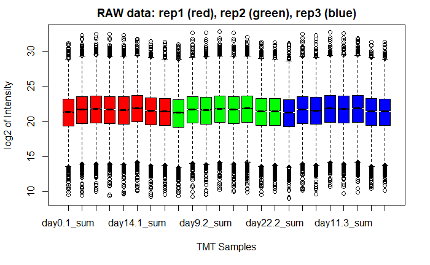

```r
##########################################################################################
rawData = proteinSet[,c(which(grepl('_sum', colnames(proteinSet))))]
rawData = rawData[,c(1,10,12,21,23,32,2:9,13:20,24:31)]
rawData[rawData == 0] = NA
rawData$accession = proteinSet$accession
rawData = subset(rawData, rowSums(is.na(rawData[,7:14])) < 5 & rowSums(is.na(rawData[,15:22])) < 5 & rowSums(is.na(rawData[,23:30])) < 5)
#rawData[is.na(rawData)] = 1
##
boxplot(log2(rawData[,7:30]), col = rep(rep(c('red', 'green', 'blue'), each = 8), 3),
        notch = TRUE, main = 'RAW data: rep1 (red), rep2 (green), rep3 (blue)',
        xlab = 'TMT Samples', ylab = 'log2 of Intensity')
```

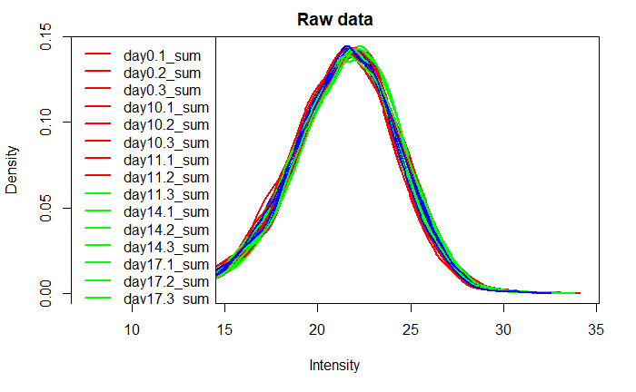

```r
##
plotDensities(log2(rawData[,7:30]), col = rep(rep(c('red', 'green', 'blue'), each = 8), 3),
              main = 'Raw data')
```

The data actually look pretty tight already. Check for column totals.

```r
##########################################################################################
format(round(colSums(rawData[,7:30], na.rm = TRUE), digits = 0), big.mark = ",")
```

```
       day0.1_sum        day7.1_sum        day9.1_sum       day10.1_sum       day11.1_sum       day14.1_sum       day17.1_sum       day22.1_sum        day0.2_sum
"114,228,219,951" "163,478,707,964" "172,867,128,936" "164,367,440,426" "157,658,341,922" "170,782,214,445" "135,439,820,285" "119,101,907,520" "103,853,614,698"
       day7.2_sum        day9.2_sum       day10.2_sum       day11.2_sum       day14.2_sum       day17.2_sum       day22.2_sum        day0.3_sum        day7.3_sum
"164,081,031,084" "154,767,713,211" "175,154,383,741" "160,850,694,943" "161,190,039,989" "126,090,548,461" "120,910,810,773" "107,715,110,171" "158,462,561,720"
       day9.3_sum       day10.3_sum       day11.3_sum       day14.3_sum       day17.3_sum       day22.3_sum
"144,897,456,360" "175,098,245,480" "167,611,596,484" "163,850,550,239" "124,524,817,455" "116,918,878,704"
```

Start off with the sample loading ‘SL’ normalization.

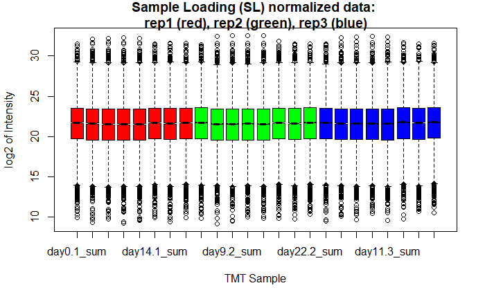

```r
##########################################################################################
# separate the TMT data by experiment
# we do not need to do this for the normalization factor calculation here,
# but we will need these data frames for the IRS step below.
exp1Raw = rawData[c(7:14)]
exp2Raw = rawData[c(15:22)]
exp3Raw = rawData[c(23:30)]

# first basic normalization is to adjust each TMT experiment to equal signal per channel
# figure out the global scaling value
target = mean(c(colSums(exp1Raw, na.rm = TRUE), colSums(exp2Raw, na.rm = TRUE), colSums(exp3Raw, na.rm = TRUE)))

# do the sample loading normalization before the IRS normalization
# there is a different correction factor for each column
normFacs = target / colSums(exp1Raw, na.rm = TRUE)
exp1Sl = sweep(exp1Raw, 2, normFacs, FUN = "*")
normFacs = target / colSums(exp2Raw, na.rm = TRUE)
exp2Sl = sweep(exp2Raw, 2, normFacs, FUN = "*")
normFacs = target / colSums(exp3Raw, na.rm = TRUE)
exp3Sl = sweep(exp3Raw, 2, normFacs, FUN = "*")

# make a pre-IRS data frame after sample loading normalizations
dataSl = cbind(exp1Sl, exp2Sl, exp3Sl)

# see what the SL normalized data look like
boxplot(log2(dataSl), col = rep(rep(c('red', 'green', 'blue'), each = 8), 3),
        notch = TRUE, main = "Sample Loading (SL) normalized data: \nrep1 (red), rep2 (green), rep3 (blue)",
        xlab = 'TMT Sample', ylab = 'log2 of Intensity')
```

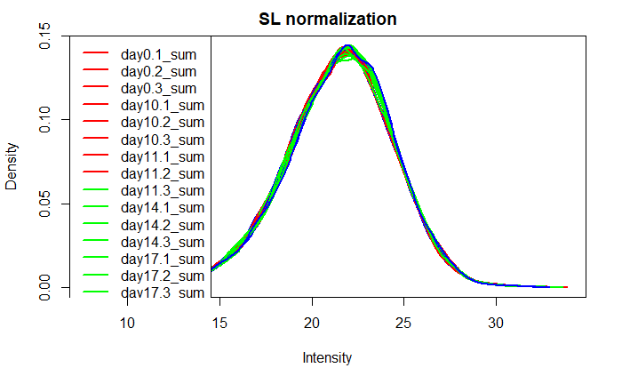

```r
# can also look at density plots (like a distribution histogram)
plotDensities(log2(dataSl), col = rep(rep(c('red', 'green', 'blue'), each = 8), 3), main = "SL normalization")
```

They look even tighter now. I think we can move onto IRS normalization now.

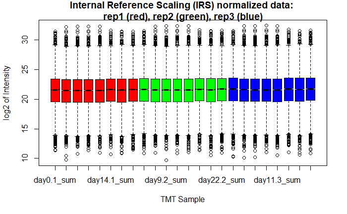

```r
##########################################################################################
# make new data frame with row sums from each frame
irs = tibble(rowSums(rawData[,1:2], na.rm = TRUE), rowSums(rawData[,3:4], na.rm = TRUE), rowSums(rawData[,5:6], na.rm = TRUE))
colnames(irs) = c('sum1','sum2','sum3')

# get the geometric average intensity for each protein
irs$average = apply(irs, 1, function(x) exp(mean(log(x),na.rm = TRUE)))

# compute the scaling factor vectors
irs$fac1 = irs$average / irs$sum1
irs$fac2 = irs$average / irs$sum2
irs$fac3 = irs$average / irs$sum3

# make new data frame with IRS normalized data
dataIrs = exp1Sl * irs$fac1
dataIrs = cbind(dataIrs, exp2Sl * irs$fac2)
dataIrs = cbind(dataIrs, exp3Sl * irs$fac3)

# see what the IRS data look like
boxplot(log2(dataIrs), col = rep(rep(c('red', 'green', 'blue'), each = 8), 3),
        main = "Internal Reference Scaling (IRS) normalized data: \nrep1 (red), rep2 (green), rep3 (blue)",
        xlab = 'TMT Sample', ylab = 'log2 of Intensity', notch = TRUE)
```

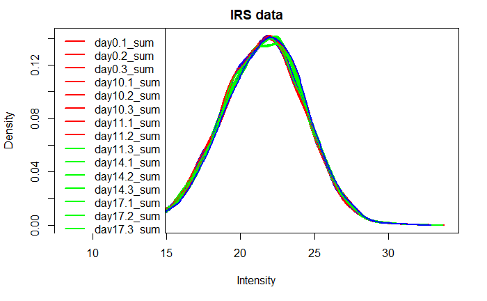

```r
# can also look at density plots (like a distribution histogram)
plotDensities(log2(dataIrs), col = rep(rep(c('red', 'green', 'blue'), each = 8), 3), main = "IRS data")
```

Now check the column totals again.

```r
##########################################################################################
format(round(colSums(dataIrs, na.rm = TRUE), digits = 0), big.mark = ",")
```

```
       day0.1_sum        day7.1_sum        day9.1_sum       day10.1_sum       day11.1_sum       day14.1_sum       day17.1_sum       day22.1_sum        day0.2_sum
"136,767,062,238" "136,763,581,392" "136,682,563,004" "136,788,620,618" "136,640,540,416" "136,755,756,896" "136,695,677,603" "136,667,061,066" "144,481,044,964"
       day7.2_sum        day9.2_sum       day10.2_sum       day11.2_sum       day14.2_sum       day17.2_sum       day22.2_sum        day0.3_sum        day7.3_sum
"144,152,371,774" "144,158,067,032" "144,068,110,282" "144,119,657,039" "144,165,016,843" "144,182,251,137" "144,462,559,023" "149,714,078,230" "150,589,823,930"
       day9.3_sum       day10.3_sum       day11.3_sum       day14.3_sum       day17.3_sum       day22.3_sum
"150,571,090,133" "150,611,191,374" "150,599,856,334" "150,114,655,853" "149,860,282,092" "149,900,492,048"
```

Take a quick look at the clustering to see how the data looks in terms of batch effects.

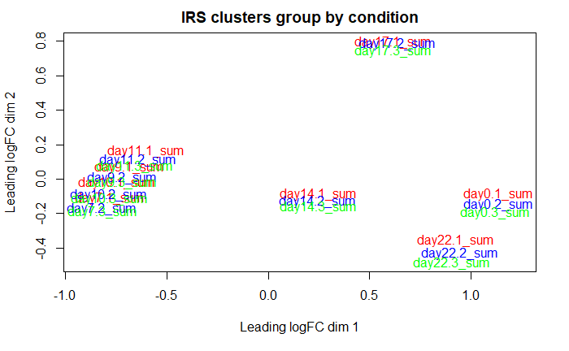

```r
##########################################################################################
# see how things cluster after IRS
colVec = c(rep('red',8),rep('blue',8),rep('green',8))
plotMDS(log2(dataIrs), col = colVec, main = "IRS clusters group by condition")
```

See if we can make this plot a bit nicer. I used [this](https://uofabioinformaticshub.github.io/DataVisualisaton_BIS2016/DataVisualisation.html) page to help with the code.

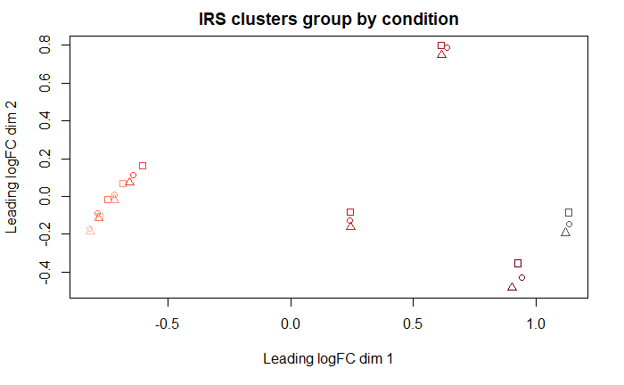

```r
##########################################################################################
#original plot
colVec = rep(c(brewer.pal(8,'Greys')[7], brewer.pal(9,'Reds')[3:9]),3)
symVec = rep(c(0,1,2), each = 8)
plotMDS(log2(dataIrs),
        col = colVec,
        pch = symVec,
        main = "IRS clusters group by condition",
        )
```

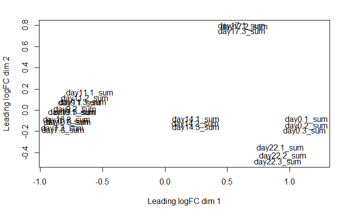

```r
#extract the data for the MDS analysis itself
mdsPlot = plotMDS(log2(dataIrs))
```

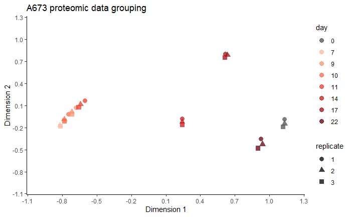

```r
mdsRawData = as.data.frame(mdsPlot@.Data[[3]])
mdsPlotData = tibble(mdsRawData) %>%
  rename(dim1 = V1, dim2 = V2) %>%
  mutate(sampleData = row.names(mdsRawData)) %>%
  mutate(day = factor(sub('day(.*)\\.[1-3]_sum$', '\\1', sampleData), levels = c(0,7,9,10,11,14,17,22))) %>%
  mutate(replicate = factor(sub('day[0-9]+\\.(.*)_sum$', '\\1', sampleData), levels = c(1,2,3)))

#make the ggplot
ggplot(mdsPlotData, aes(dim1, dim2, color = day, shape = replicate)) +
  geom_point(size = 3, alpha = 0.75) +
  scale_color_manual(values = rep(c(brewer.pal(8,'Greys')[7], brewer.pal(9,'Reds')[3:9]),3)) +
  scale_x_continuous(limits = c(-1,1.2), breaks = seq(-2,2,0.3)) +
  scale_y_continuous(limits = c(-1,1.2), breaks = seq(-2,2,0.3)) +
  labs(x = 'Dimension 1', y = 'Dimension 2', title = 'A673 proteomic data grouping') +
  theme_classic()
#save the plot
  ggsave(paste(baseRepository, '/proteomics20201223_a673ShEwsFli1DoxTimecourseSetA/mdsplot_a673ShEwsFli1AbundanceIrs.pdf', sep = ''),
         height = 4, width = 4, useDingbats = FALSE)
```

So the data look great. There is doesn’t appear to be any batch/replicate effect (y-axis), and the individual days themselves seem to be driving the biggest difference (x-axis)

Recombine the data with the accessions and look at a few target proteins.

```r
##########################################################################################
proteinAnnotation = readRDS(paste(baseRepository, '/proteomics20201223_a673ShEwsFli1DoxTimecourseSetA/uniprotHumanJan2021.fasta.annotated.rds', sep = ''))
finalIrsData = as_tibble(cbind(rawData$accession, dataIrs)) %>%
  rename(accession = `rawData$accession`) %>%
  left_join(proteinAnnotation) %>%
  left_join(proteinSet[,c(1,22,44,66)])
finalIrsData[grepl('DLG2', finalIrsData$gene),]
```

| accession | day0.1_sum | day7.1_sum | day9.1_sum | day10.1_sum | day11.1_sum | day14.1_sum | day17.1_sum | day22.1_sum | day0.2_sum | day7.2_sum | day9.2_sum | day10.2_sum | day11.2_sum | day14.2_sum | day17.2_sum | day22.2_sum | day0.3_sum | day7.3_sum | day9.3_sum | day10.3_sum | day11.3_sum | day14.3_sum | day17.3_sum | day22.3_sum | gene | species | length | detectablePeptides | detectableLength | … |
| --- | --- | --- | --- | --- | --- | --- | --- | --- | --- | --- | --- | --- | --- | --- | --- | --- | --- | --- | --- | --- | --- | --- | --- | --- | --- | --- | --- | --- | --- | --- |
| Q15700 | 8033156 | 1081907 | 1492767 | 1361520 | 1725187 | 4078183 | 5201462 | 5849634 | 9402138 | 1105015 | 1614440 | 1395772 | 1910190 | 4587271 | 6122354 | 6458236 | 9818486 | 1069508 | 1669279 | 1490803 | 1972785 | 4781156 | 6248776 | 6681047 | DLG2 | human | 870 | 50 | 619 | … |

```r
##save data
saveRDS(finalIrsData, paste(baseRepository, '/proteomics20201223_a673ShEwsFli1DoxTimecourseSetA/dataset_proteinSetABCIrsNormalized.rds', sep = ''))
```

[session information not shown]